# Accurate vs Agreeing advice (Dots task)

Matt Jaquiery (matt.jaquiery@psy.ox.ac.uk)

June 2020  
[Script run 2020-06-29 16:46:40]

# Descriptives

## Introduction

Investigation using the Dates task indicated that people showed a strong preference for picking accurate over agreeing advisors when feedback was provided. When feedback was withheld, no systematic preference was seen. Here we investigate whether the same pattern of results is observed when the Dots (perceptual decision-making) task is used instead.

## Load data

```
## Loaded data from G:\Documents\University\Google Drive\Temp\data\processed
```

```
## Generated utility variables
```

## Describe data

### Metadata

Responses (*N* = 89) were collected between 2020-06-18 10:43:31 and 2020-06-23 13:59:57.

Demographic data are not collected and therefore not analysed. Participants must be over 18 years old to use the Prolific recruitment platform.

### Task performance

#### Type 1 performance

Participants initial performance was held at 71% by design. Participants’ mean percentage correct on initial decisions was *M* = .72 [0.71, 0.72]. We would expect final decisions to be more accurate due to the presence of advice:

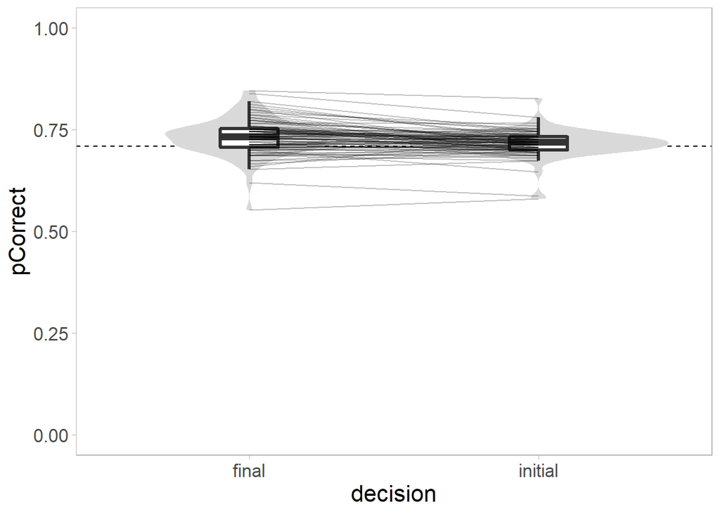

#### Type 2 performance

Type 2 (metacognitive) performance is characterised using Type 2 ROC.

| decision | pCorrect |
| --- | --- |
| initial | .744 |
| final | .737 |

Participants’ ROC curves:

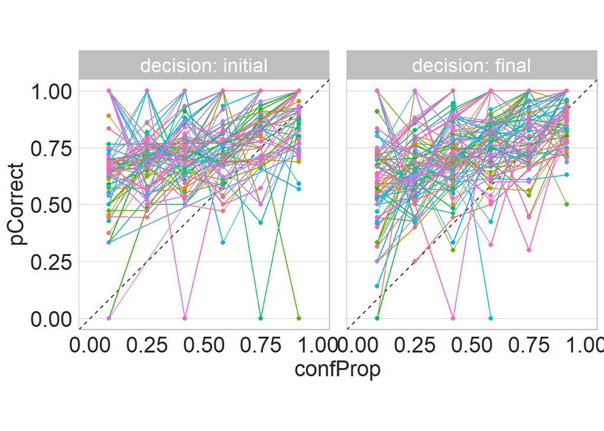

### Exclusions

We exclude participants for:

- Proportion of correct initial judgements must be (.60 < cor1/n < .90) (*N* = 1)
- Having fewer than 3 confidence categories (*N* = 6)
- Having fewer than 5% of trials in each confidence category (*N* = 2)

*NB: **practice trials are included** in this since they are used in part for determining confidence calibration*

The number of participants analysed after exclusions (total *N* = 9) have taken place is 80.

### Advisor performance

#### Manipulation checks

The advisors need to differ appropriately. How they differ depends on the advisors being compared, but in each case we need to check the participants’ experience of the advisors matched the specifications for the advisors.

| adviceTypeName | property | y | ymin | ymax |
| --- | --- | --- | --- | --- |
| avaAcc | agr | .633 | .621 | .646 |
| avaAcc | acc | .799 | .790 | .809 |
| avaAgr | agr | .805 | .794 | .816 |
| avaAgr | acc | .630 | .616 | .643 |

#### Initial decision comparability

The participants’ initial decisions should be equivalent (BF < .333) between advisors. Comparing initial decision by advice profile we can see whether this was the case:

BF = 0.23; *M*|avaAcc = .71 [0.70, 0.72], *M*|avaAgr = .72 [0.71, 0.73]

# Pick rate differences

The primary outcome is the relative frequencies of advisor picking on trials where there is a choice of advisor. *Choice* trials show participants two advisors and wait until the participant selects one.

## Choice trials

Analysis for choice trials is conducted by comparing the proportion of choices for a reference advisor to the null hypothesis of .50 using a one-sample t-test.

[1] “P(choose accurate)”

| feedbackCondition | y | ymin | ymax |
| --- | --- | --- | --- |
| no-feedback | .515 | .403 | .628 |
| feedback | .553 | .464 | .642 |

*t*(44) = 1.21, *p* = .233, *d* = 0.18, BF = 0.32; *M*|feedback = 0.55 [0.46, 0.64], $\mu$ = 0.5

*t*(34) = 0.28, *p* = .784, *d* = 0.05, BF = 0.19; *M*|no-feedback = 0.52 [0.40, 0.63], $\mu$ = 0.5

*t*(69.34) = 0.54, *p* = .592, *d* = 0.12, BF = 0.27; *M*|feedback = 0.55 [0.46, 0.64], *M*|no-feedback = 0.52 [0.40, 0.63]

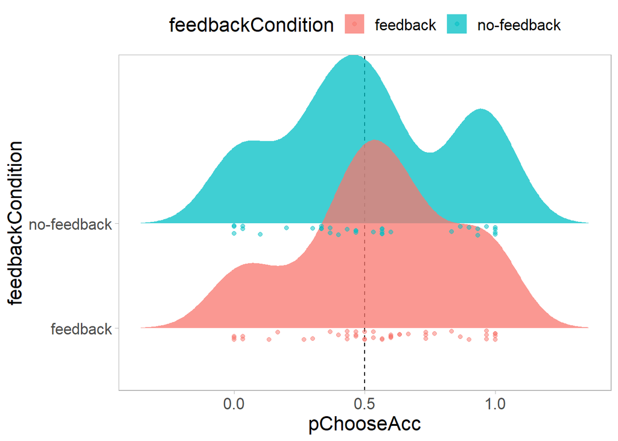

## Summary

Participants do not seem to have learned about the differences in the advisors during the training phase, even with feedback. Despite efforts to make the advisors more salient by introducing them one at a time and by adding identicons, no clear preference emerged for either advisor, even in the Feedback condition.

# Influence differences

Influence, defined as the extent to which a participant adjusts their answer in the direction of an advisor’s advice, can be compared between advisors. Note that the experimental design is not optimised for measuring this outcome because influence may vary systematically with choices, and the trials without choices constitute a learning phase wherein preferences cannot be expected to have crystalised.

Influence scores are compared for trials on which a choice is not presented. For forced trials analysis is a simple ANOVA of agreement * advice profile:

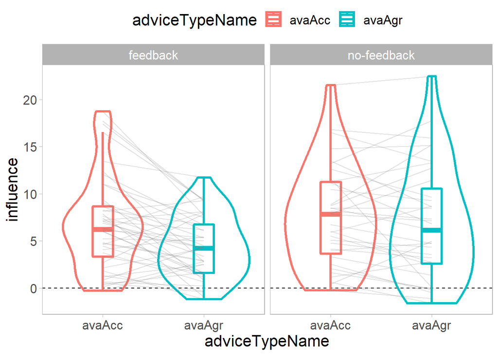

```
## $ANOVA
##                             Effect DFn DFd         F            p p<.05
## 2                feedbackCondition   1  78  2.671986 0.1061583319
## 3                   adviceTypeName   1  78 15.743015 0.0001600651     *
## 4 feedbackCondition:adviceTypeName   1  78  3.909626 0.0515434898
##           ges
## 2 0.028712803
## 3 0.026915705
## 4 0.006822281
```

## Summary

# Pick rate x Influence

If picking and influence measure a single latent ‘trust’ estimation for an advisor, the ratings should be correlated. The analysis is by advisor ID rather than advice profile, because individual advisors should have pick rates and influences which are more tightly correlated than advice profiles which average over multiple advisors.

Forced trials are used for the influence calculations, and choice trials for the pick rate calculations.

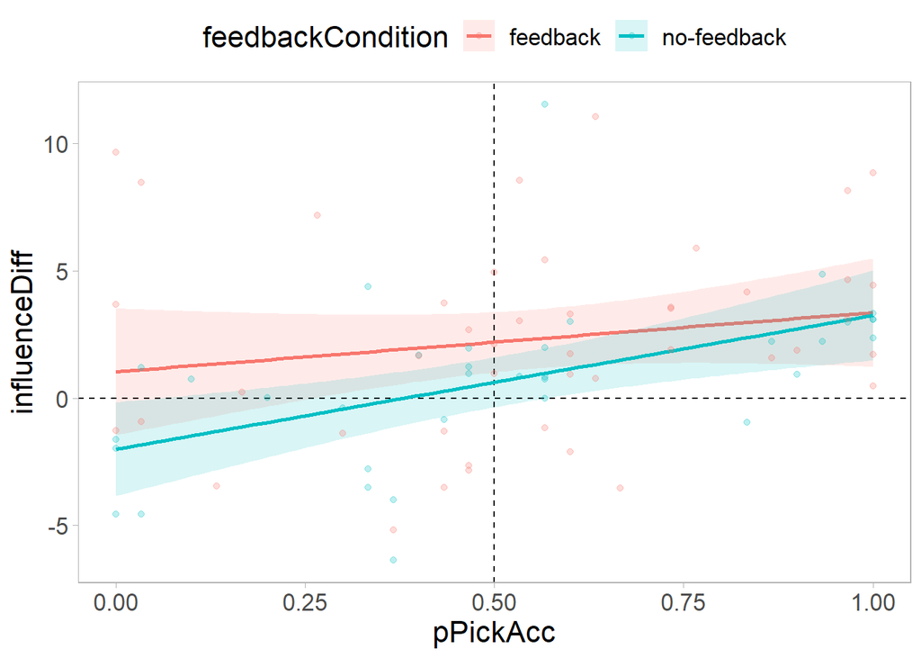

```
## # A tibble: 4 x 7
##   feedbackCondition d      term        estimate std.error statistic p.value
##   <chr>             <list> <chr>          <dbl>     <dbl>     <dbl>   <dbl>
## 1 no-feedback       <lm>   (Intercept)    -2.00     0.905    -2.22  0.0337
## 2 no-feedback       <lm>   pPickAcc        5.25     1.49      3.53  0.00126
## 3 feedback          <lm>   (Intercept)     1.04     1.23      0.841 0.405
## 4 feedback          <lm>   pPickAcc        2.32     1.97      1.18  0.246
```

# Credits

## Acknowledgements

Thanks as always to Nick Yeung and the other folks at the [ACC Lab](https://www.psy.ox.ac.uk/research/attention-cognitive-control-lab).

## R Packages

[output not shown]

## Funding

Matt Jaquiery is funded by a studentship from the [Medical Research Council](https://mrc.ukri.org/) (reference 1943590) and the University of Oxford [Department of Experimental Psychology](https://www.psy.ox.ac.uk/) (reference 17/18_MSD_661552).